# Time Series – Group Project || Prof. Francesca Lipari

José Ignacio Díez Ruíz – 100487766

Carlos Roldán Piñero – 100484904

Pablo Vidal Fernández – 100483812

Jialian Zhou He – 100407485

February 2023

# Exercise 1

> Use the appropiate graphics functions, explore features from the following time series: **bicoal**, **bricksq**, **hsales**, **ibmclose**, **Internet**, **writing**.
> - Can you spot any seasonality, cyclicity and trend?
> - What do you learn about the time series?
> - Justify the choice of the graphic function.

## Bicoal TS

According to the documentation, this time series contains the annual bituminous coal production in the USA between 1920 and 1968.

We check that the frequency of the time series is annual:

```r
frequency(bicoal)
```

```
## [1] 1
```

Plotting the series and the first differences:

```r
p1 <- autoplot(bicoal, main = "Bituminous coal production \nin the USA",
               xlab = "Year",
               ylab = "Bicoal")

p2 <- autoplot(diff(bicoal), main = "Bituminous coal
               production  \nin the USA",
               xlab = "Year",
               ylab = "First difference")
```

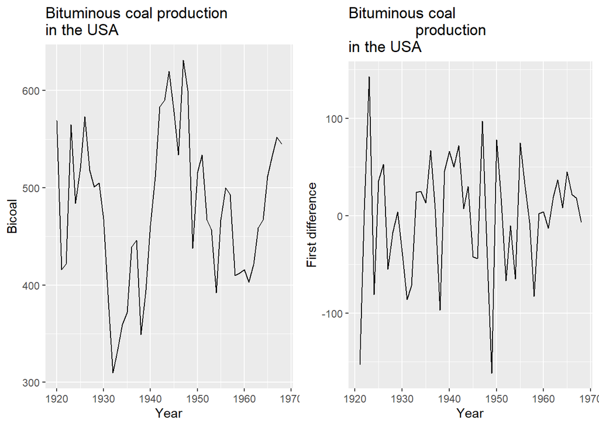

Bicoal

```r
ggarrange(p1, p2, ncol = 2)
```

It is annual data, therefore it cannot be seasonal.

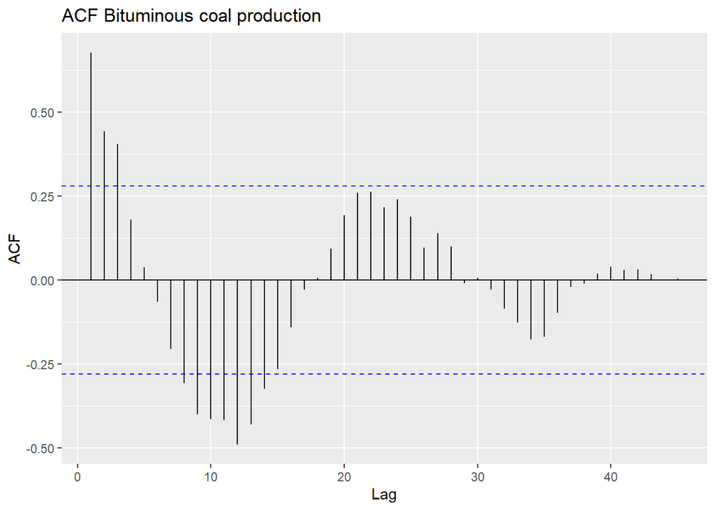

Bicoal ACF

```r
ggAcf(bicoal, lag.max = 45) + ggtitle("ACF Bituminous coal production")
```

We can observe a sinusoidal pattern, and it goes towards zero. It seems that this time series is stationary, with a cyclic component.

## Bricksq TS

According to the documentation, this time series contains the Australian quarterly clay brick production between 1956 and 1994.

We check that the frequency of the time series is quarterly.

```r
frequency(bricksq)
```

```
## [1] 4
```

Plotting the series:

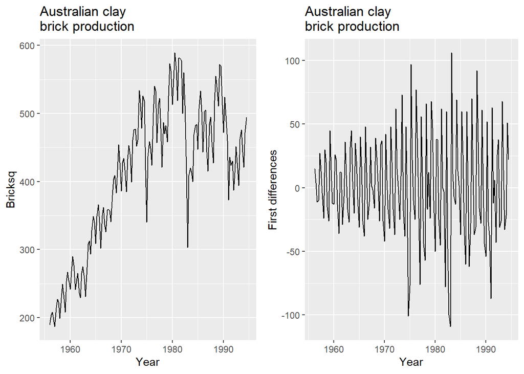

Bricksq plot

```r
par(mfrow=c(1,2))
p3 <- autoplot(bricksq, main = "Australian clay \nbrick production",
               xlab = "Year",
               ylab = "Bricksq")
p4 <- autoplot(diff(bricksq, lag = 1),
               main = "Australian clay \nbrick production",
               xlab = "Year",
               ylab = "First differences")
ggarrange(p3, p4, ncol = 2)
```

Looking at the plot, we can see that there might be a seasonal component and a trend. The series doesn’t appear to be stationary. It also seems that there is heterocedasticity.

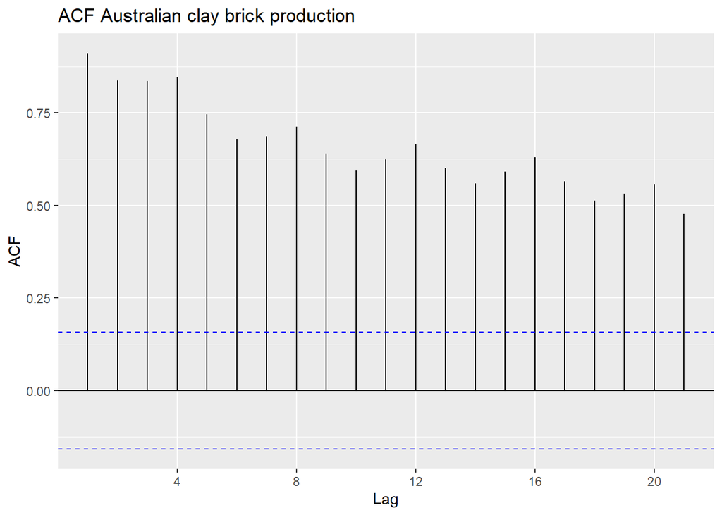

ACF bricksq

```r
ggAcf(bricksq) + ggtitle("ACF Australian clay brick production")
```

As the autocorrelations for the first lags are large and they slowly decrease, we can say that there is a trend. Moreover, we can see that each 4 lags the autocorrelation is higher, a sign of seasonality.

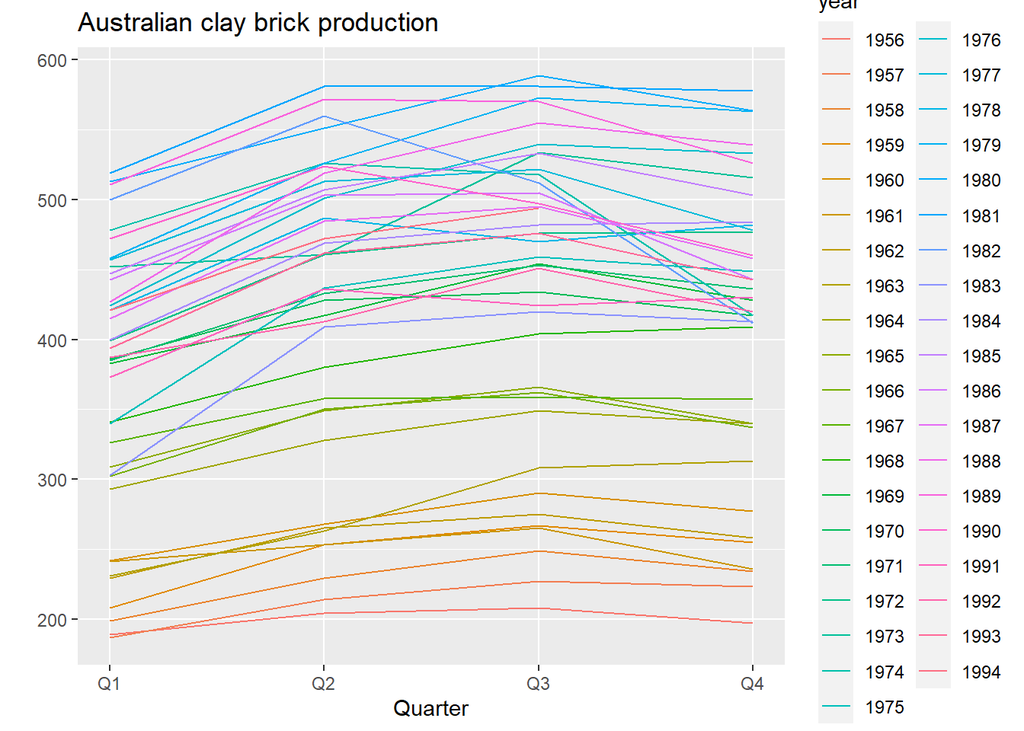

Bricksq seasonal plot

```r
p5 <- ggseasonplot(bricksq) +
    ggtitle("Australian clay brick production")
p5
```

We can appreciate this more clearly in the subseries plot:

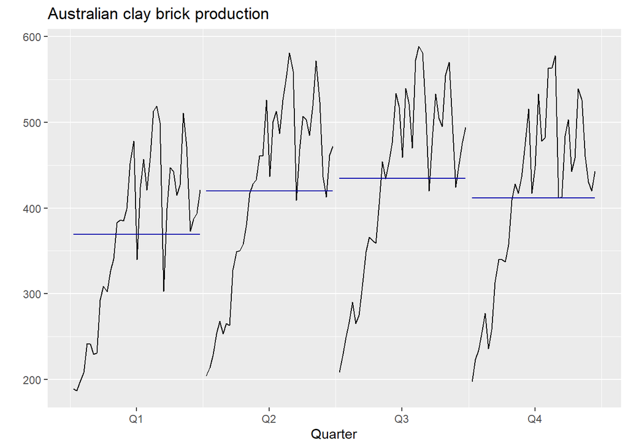

Bricksq subseries plot

```r
p6 <- ggsubseriesplot(bricksq, ylab = "",
                      main = "Australian clay brick production")
p6
```

## Hsales TS

According to the documentation, this time series contains the monthly sales of new one-family houses sold in the USA since 1973.

We check that the frequently is monthly:

```r
frequency(hsales)
```

```
## [1] 12
```

We have monthly data, thus a seasonal component might exist.

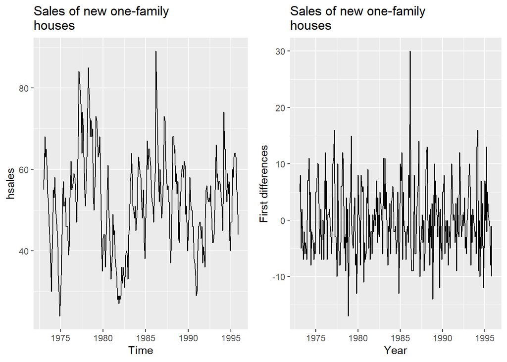

Plot for hsales

```r
p7 <- autoplot(hsales, main = "Sales of new one-family \nhouses")
p8 <- autoplot(diff(hsales, lag = 1),
               main = "Sales of new one-family \nhouses",
               xlab = "Year",
               ylab = "First differences")

ggarrange(p7, p8, ncol = 2)
```

At a first glance, we can see a cyclical component in the series. There doesn’t appear to be any trend. Moreover, a seasonal component can be appreciated within each year.

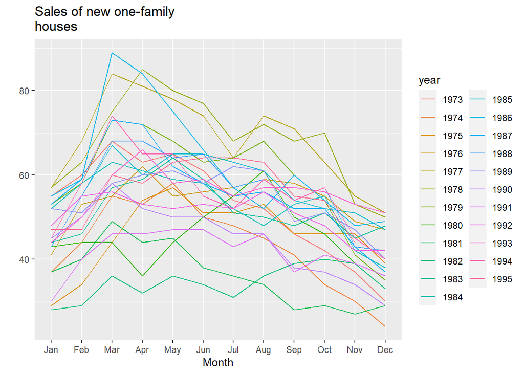

Hsales season plot

```r
p9 <- ggseasonplot(hsales,
                   main = "Sales of new one-family \nhouses")
p9
```

We can see that March and April tend to be the months with higher volume, whereas the last months of the year come with a decrease. In August, there seems to be a recuperation with respect to July.

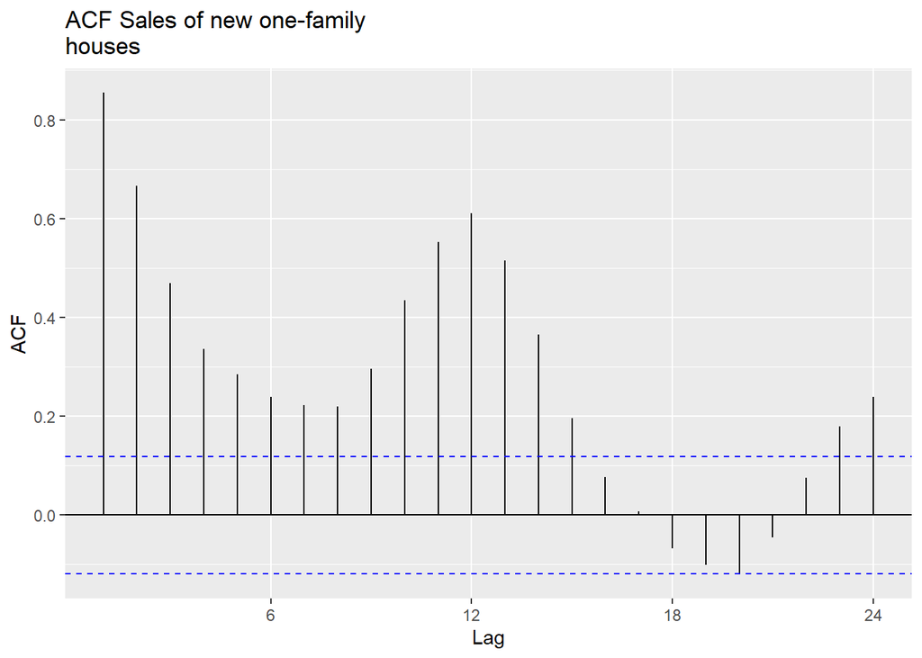

ACF Hsales

```r
p10 <- ggAcf(hsales) +
    ggtitle("ACF Sales of new one-family \nhouses")
p10
```

There are peaks at 12 and 24 in the correlogram, confirming seasonality. There is no evidence for a trend.

## Ibmclose TS

According to the documentation, the series contains the daily closing IBM stock price.

We check that the frequency is daily:

```r
frequency(ibmclose)
```

```
## [1] 1
```

Plotting the series:

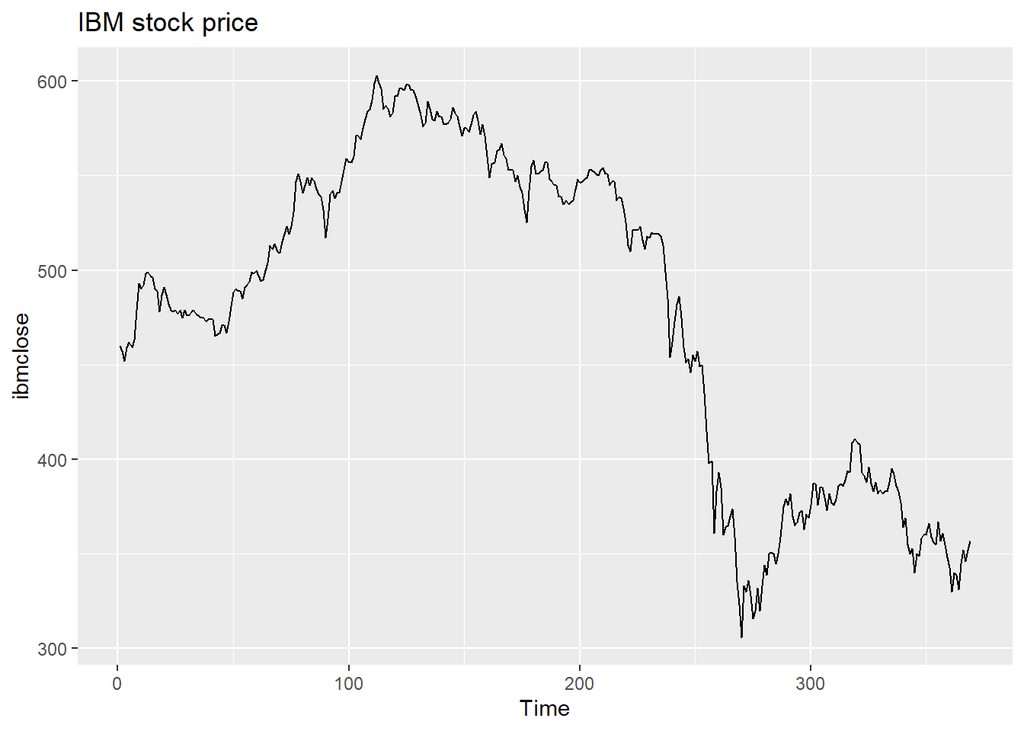

Plot for ibmclose

```r
autoplot(ibmclose, main = "IBM stock price")
```

The data is daily, so there can’t be a seasonal nor cyclic component. It looks like there is a negative trend, although it doesn’t seem to be linear.

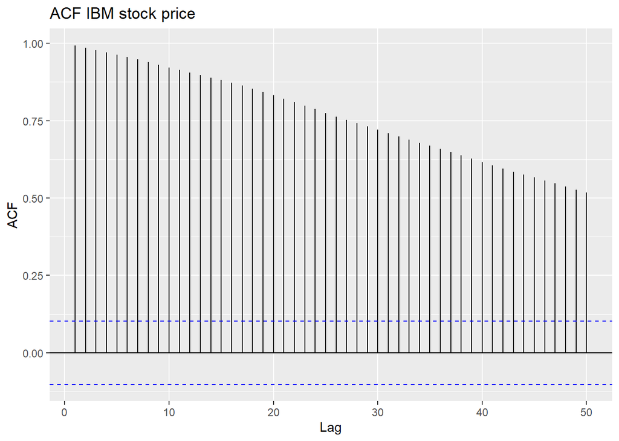

ACF ibmclose

```r
ggAcf(ibmclose, lag.max = 50) + ggtitle("ACF IBM stock price")
```

The series is definitely not stationary. Correlations are very high and don’t go rapidly towards zero, confirming that there is a trend.

## Internet TS

Using *help*, we can see that the dataset contains the number of user logged on to an internet server each minute over a 100-minute period. Consequently, there won’t be a cyclic or seasonal component.

```r
frequency(internet)
```

```
## [1] 1
```

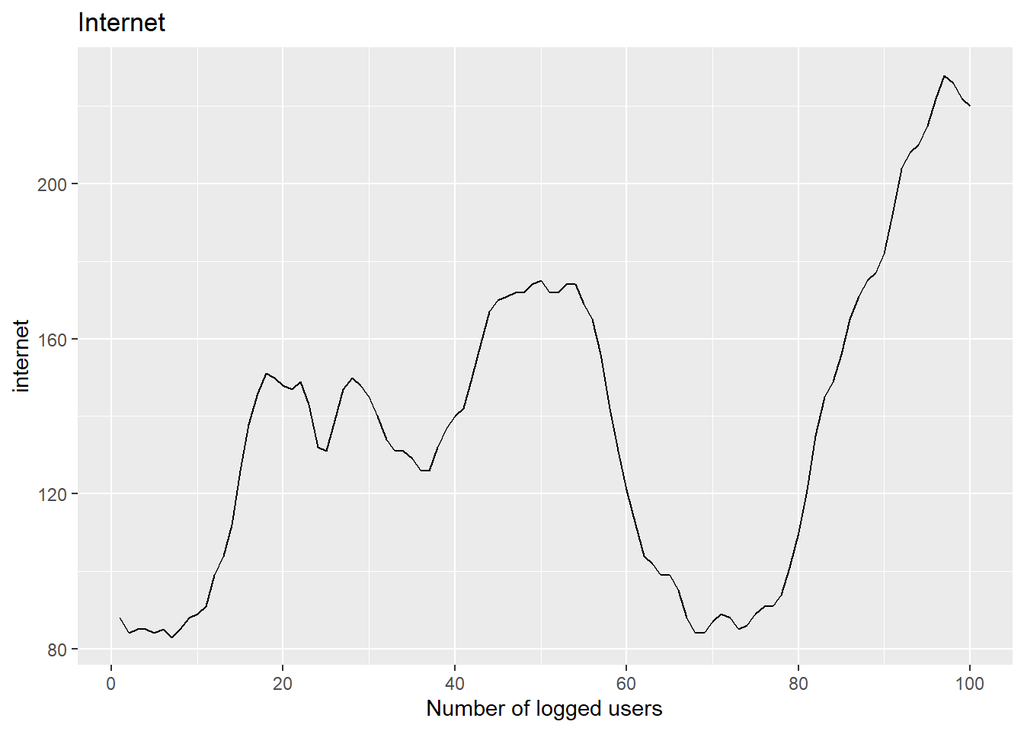

Plot for internet

```r
autoplot(internet,
         xlab = "Number of logged users",
         main = "Internet")
```

It doesn’t look like there is a trend. The series goes up, then goes down and finally it starts rising again.

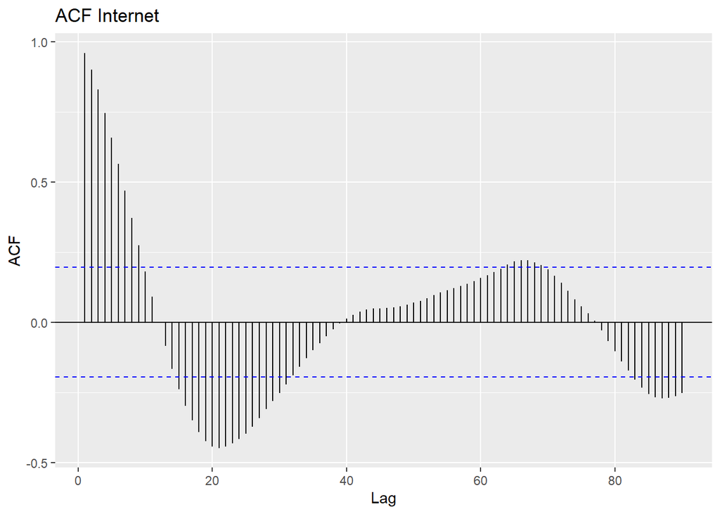

ACF internet

```r
ggAcf(internet, lag.max = 90) +
    ggtitle("ACF Internet")
```

We can see oscillations between positive and negative autocorrelations, consistent with the ups and downs in the series. It doesn’t go rapidly towards zero, so the data is not stationary.

## Writing TS

Checking that the frequency is monthly:

```r
frequency(writing)
```

```
## [1] 12
```

Plotting the data:

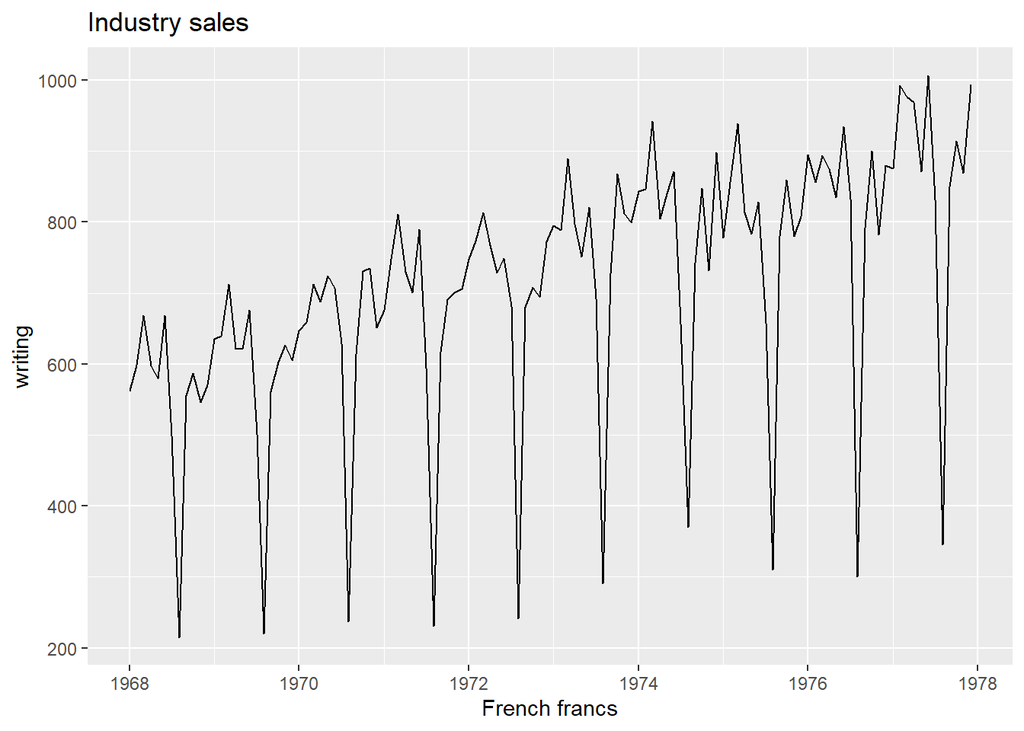

Plot for writing

```r
autoplot(writing,
         main = "Industry sales",
         xlab = "French francs")
```

We can see a positive linear trend, a strong seasonality and there doesn’t seem to be a cyclic component.

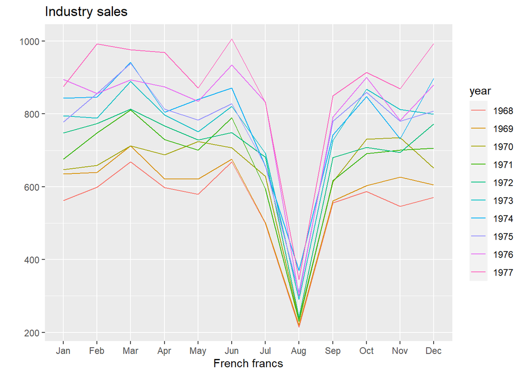

Writing seasonplot

```r
ggseasonplot(writing,
             main = "Industry sales",
             xlab = "French francs")
```

In this plot, we can appreciate that each year, values keep getting higher, so there is a positive trend. Furthermore, there is always a big drop in August, possibly related to the vacation period of workers.

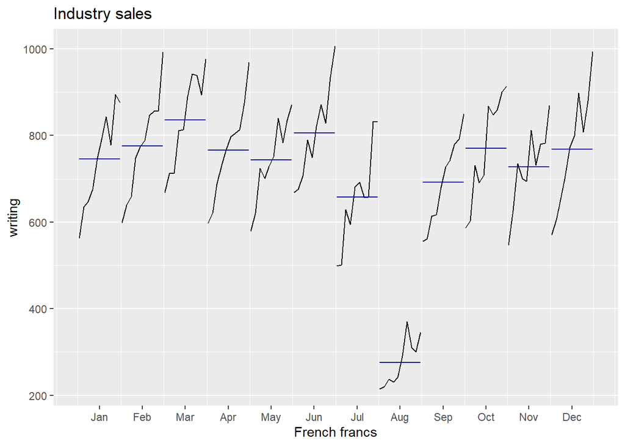

Writing subseries plot

```r
ggsubseriesplot(writing,
                main = "Industry sales",
                xlab = "French francs")
```

We can see the same information in the subseries plot.

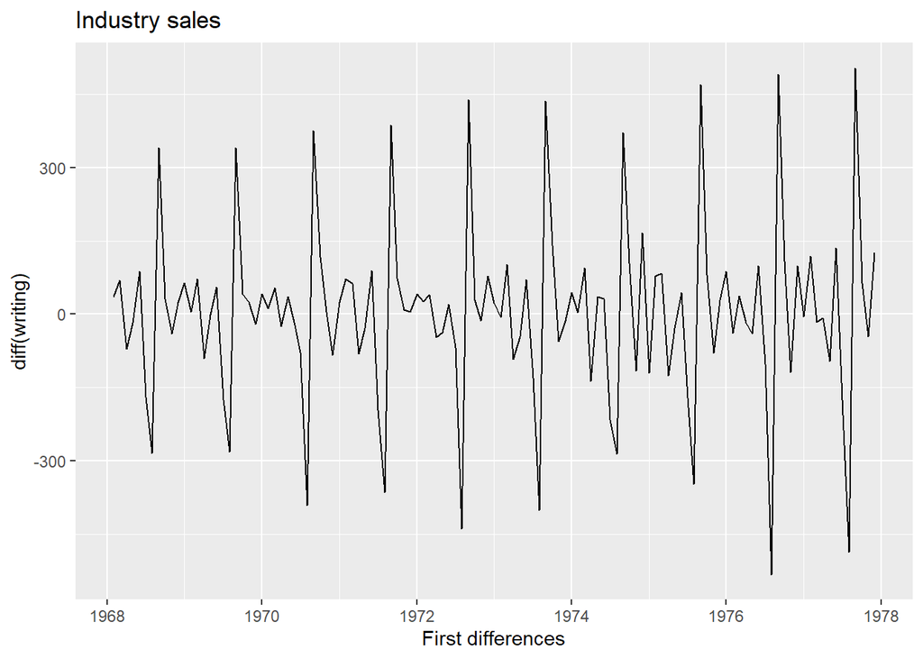

Writing first differences

```r
autoplot(diff(writing),
         main = "Industry sales",
         xlab = "First differences")
```

We can see in the first differences series that variability also grows as time passes, hence we have heterocedasticity.

The correlogram:

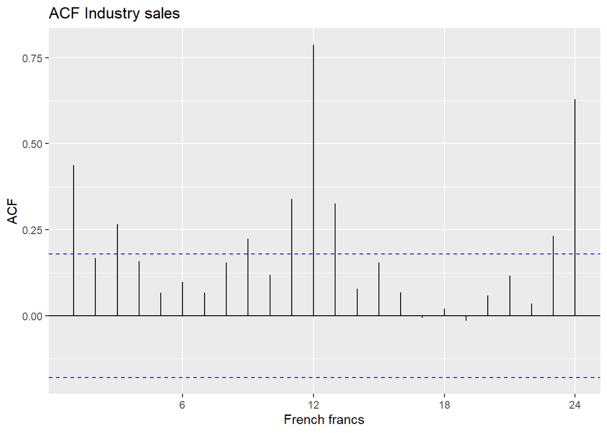

ACF writing

```r
ggAcf(writing) +
    ggtitle("ACF Industry sales") +
    xlab("French francs")
```

Peaks at 12 and 24 confirm the seasonality.

# Exercise 2

# Exercise 3

> For each of the following series, make a graph of the data with forecasts using the most appropriate of the four benchmark methods: mean, naive, seasonal naive or drift.
> 1. Monthly total of people on unemployed benefits in Australia (January 1956 - July 1992). Data set **dole**.
> 2. Annual Canadian lynx trappings (1821 - 1934). Data set **lynx**.

> In each case, do you think the forecasts are reasonable? If not, how could they be improved?

## (a)

We are going to start by plotting the data, using time, seasonal and subseries plots.

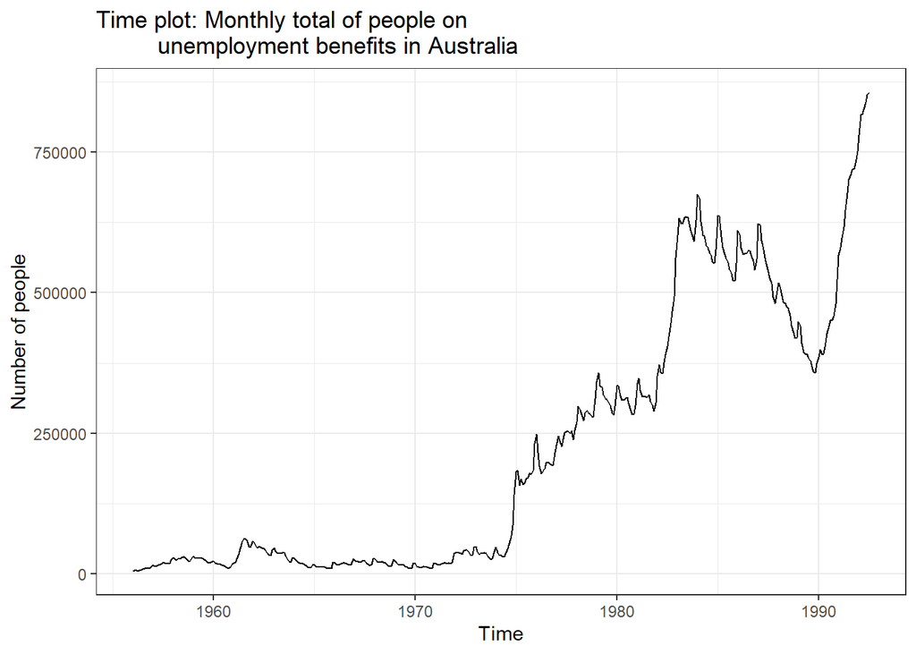

Time plot for the monthly total of people on unemployment benefits in Australia.

```r
autoplot(dole, main = "Time plot: Monthly total of people on
         unemployment benefits in Australia",
        xlab = "Time",
        ylab = "Number of people") + theme_bw()
```

```r
dole_seasonal  <- ggseasonplot(dole,
        main = "Seasonal plot: Monthly total of people\non
        unemployment benefits in Australia",
        xlab = "Time",
        ylab = "Number of people") + theme_bw()
dole_pseasonal <- ggseasonplot(dole,
        main = "Seasonal plot (polar): Monthly total
        of people \non unemployment benefits in Australia",
        xlab = "Time",
        ylab = "Number of people",
        polar = T) + theme_bw()
```

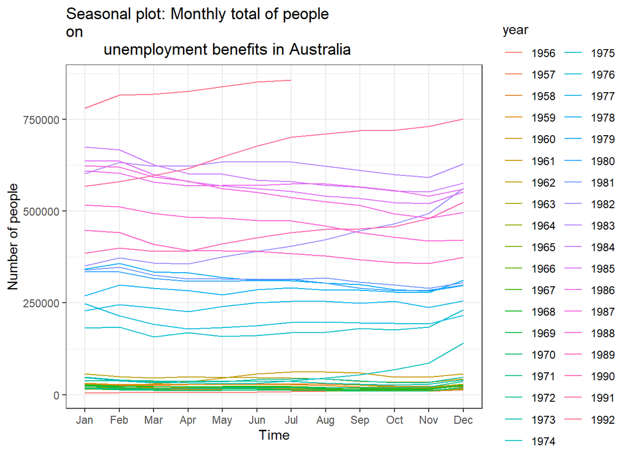

Seasonal plot of monthly total of people on unemployment benefits in Australia

```r
plot(dole_seasonal)
```

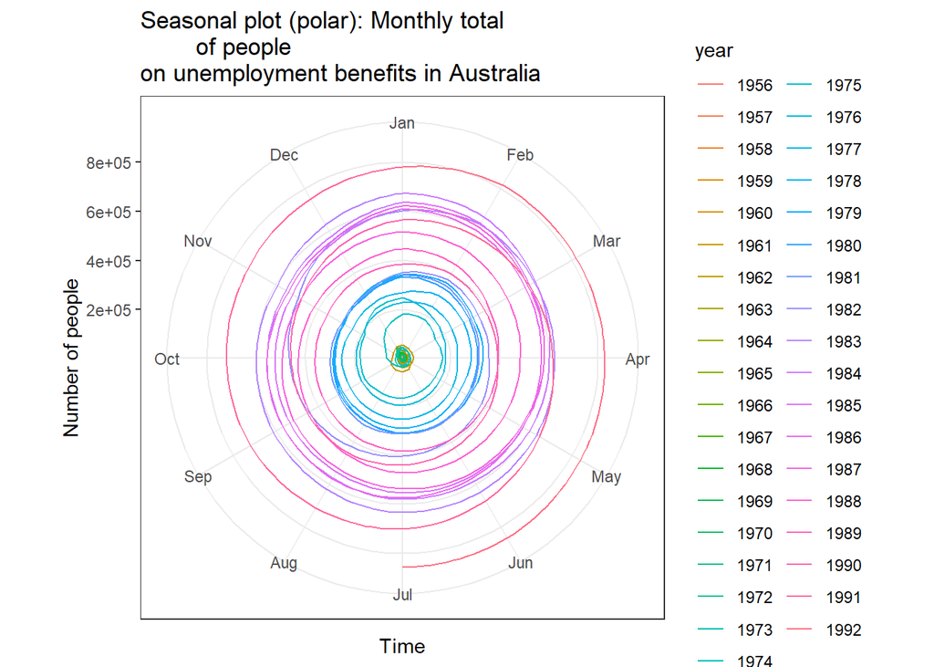

Seasonal polar plot of monthly total of people on unemployment benefits in Australia

```r
plot(dole_pseasonal)
```

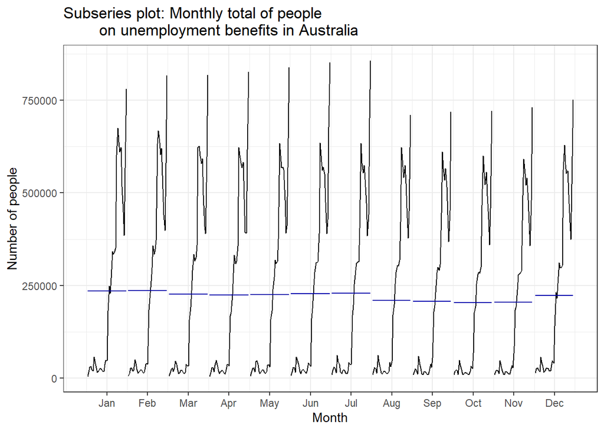

Subseries plot for the monthly total of people on unemployment benefits in Australia

```r
plot(ggsubseriesplot(dole,
        main = "Subseries plot: Monthly total of people
        on unemployment benefits in Australia",
        xlab = "Month",
        ylab = "Number of people",) + theme_bw())
```

We can observe a clearly positive trend over time, as well as an apparent lack of seasonality. Also, in the subseries, we do not see such high peaks in the months from August to December, unlike the rest of the months. However, this is because we only have data up to July 1992, which seems to coincide with a period of significant rise in people on unemployment benefits.

It may also be worth noting that there is usually an increase in the month of December. This can also be seen in the plot subseries, where, although the month of December does not have the data corresponding to the last year (which probably increased its average value), it has an average value similar to those of the months from January to July, which do have the data for the last year. If we remove the data from the last year, it is more clear.

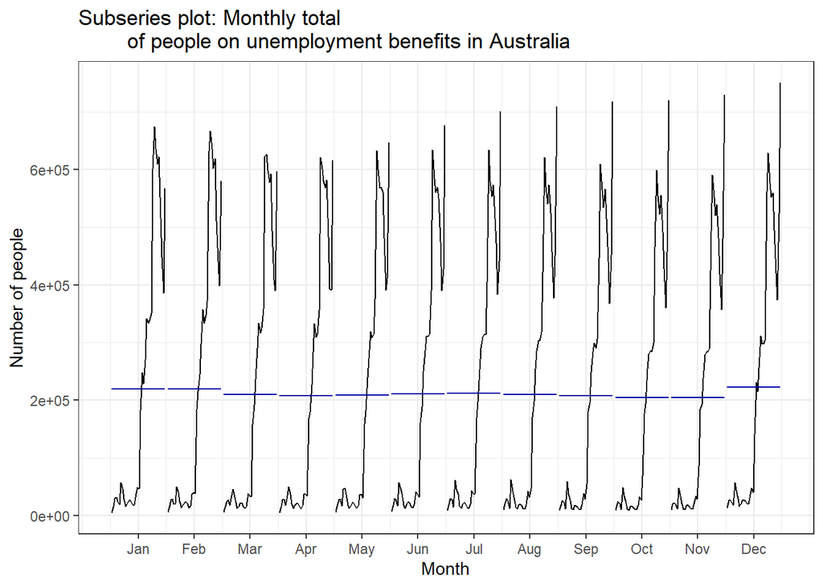

Subseries plot for the monthly total of people on unemployment benefits in Australia (from 1956 to the end of 1991)

```r
plot(ggsubseriesplot(window(dole, 1956, c(1991,12)), # not selecting the last year
        main = "Subseries plot: Monthly total
        of people on unemployment benefits in Australia",
        xlab = "Month",
        ylab = "Number of people",) + theme_bw())
```

Next, we will look the ACF:

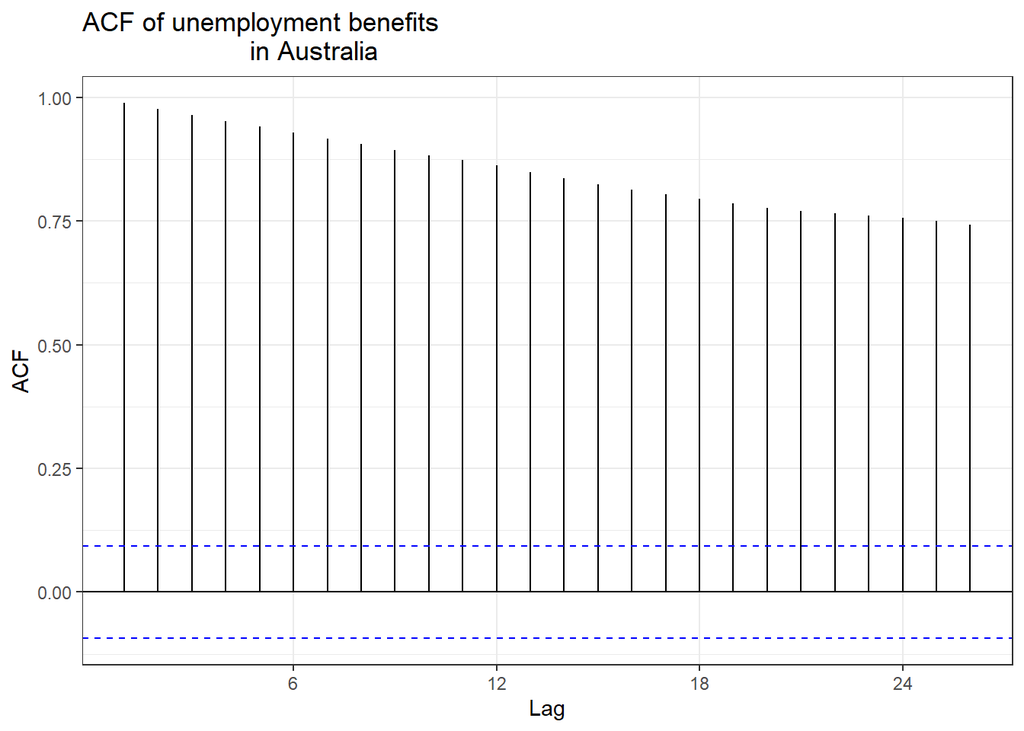

ACF of unemployment benefits in Australia

```r
ggAcf(dole) + ggtitle("ACF of unemployment benefits
                      in Australia") +  theme_bw()
```

The ACF confirms the positive trend as, when data have a trend, the autocorrelations for small lags tend to be large and positive (due to observations nearby in time are also nearby in size). Also, the ACF of trended time series tend to have positive values that slowly decrease as the lags increase.

Based on this plot, we may think that the most appropiate methods will be the naive methods.

Now, we are going to do the predictions for the next 24 months using the four methods:

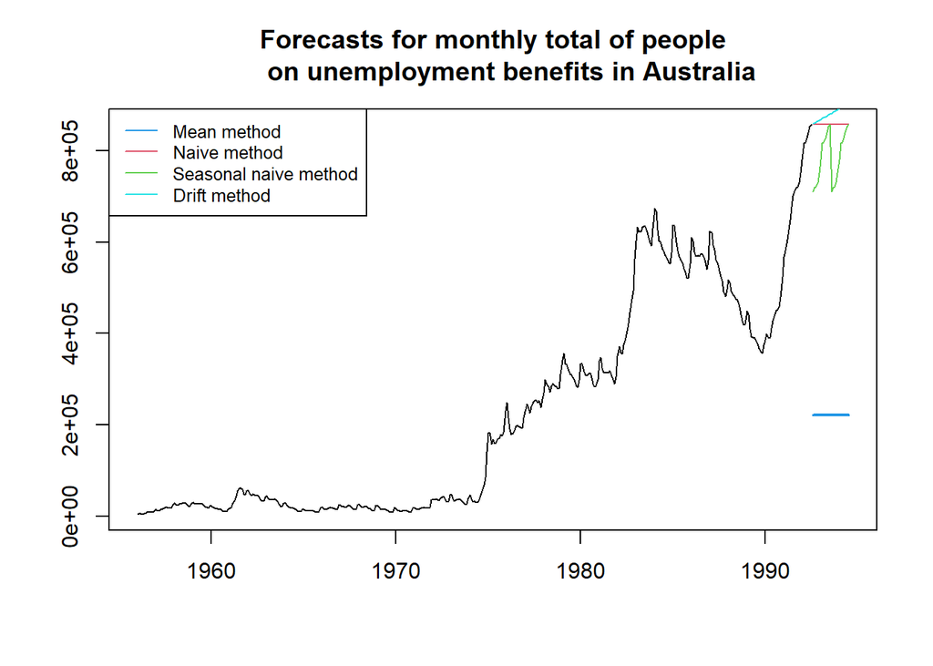

Forecast for monthly total of people on unemployment benefits in Australia

```r
dole_mean   <- meanf(dole,h=24)
dole_naive  <- naive(dole,h=24)
dole_snaive <- snaive(dole,h=24)
dole_drift  <- rwf(dole,h=24,drift=TRUE)

plot(dole_mean, PI=FALSE, main="Forecasts for monthly total of people
     on unemployment benefits in Australia")
lines(dole_naive$mean, col=2)
lines(dole_snaive$mean, col=3)
lines(dole_drift$mean, col=5)
legend("topleft", lty=1, cex = .8, col=c(4,2,3,5),
       legend=c("Mean method","Naive method",
                "Seasonal naive method","Drift method"))
```

At first glance, none of the methods seem particularly good, with the mean method being perhaps the worst. Based on the graph, it seems unlikely that any of the predictions will be fulfilled, with the drift method being the one that seems closest to what could happen.

We now check the residuals.

```r
summary(residuals(dole_mean))
```

```
##    Min. 1st Qu.  Median    Mean 3rd Qu.    Max.
## -216496 -200838 -164483       0  171383  635267
```

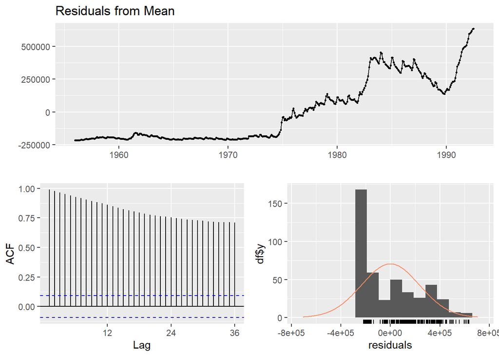

Residuals obtained with the mean method in the dole dataset

```
##
##  Ljung-Box test
##
## data:  Residuals from Mean
## Q* = 8081.1, df = 23, p-value < 2.2e-16
##
## Model df: 1.   Total lags used: 24
```

```r
checkresiduals(dole_mean)
```

```r
summary(residuals(dole_naive))
```

```
##     Min.  1st Qu.   Median     Mean  3rd Qu.     Max.     NA's
## -40406.0  -3115.2   -422.5   1944.7   4315.8  69146.0        1
```

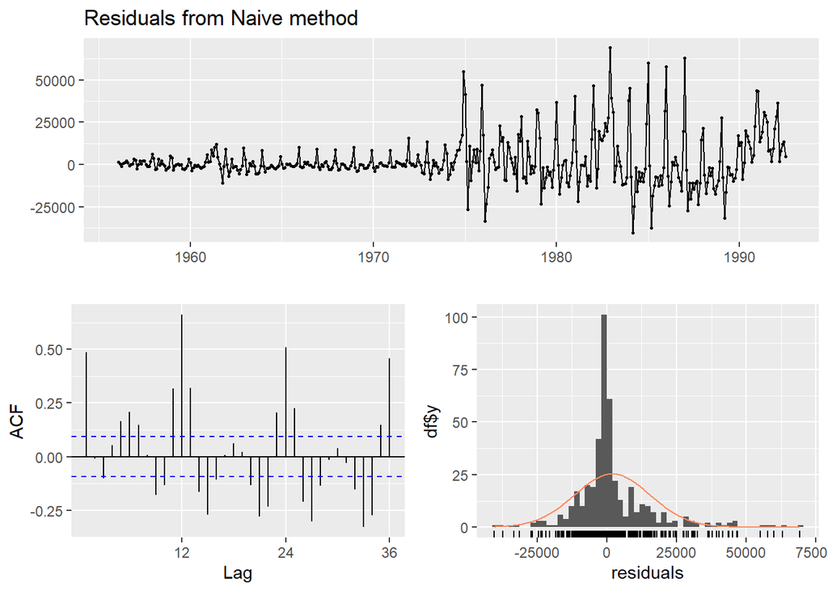

Residuals obtained with the naive method in the dole dataset

```
##
##  Ljung-Box test
##
## data:  Residuals from Naive method
## Q* = 725.9, df = 24, p-value < 2.2e-16
##
## Model df: 0.   Total lags used: 24
```

```r
checkresiduals(dole_naive)
```

```r
summary(residuals(dole_snaive))
```

```
##    Min. 1st Qu.  Median    Mean 3rd Qu.    Max.    NA's
## -108955   -9246    3751   21827   28572  266444      12
```

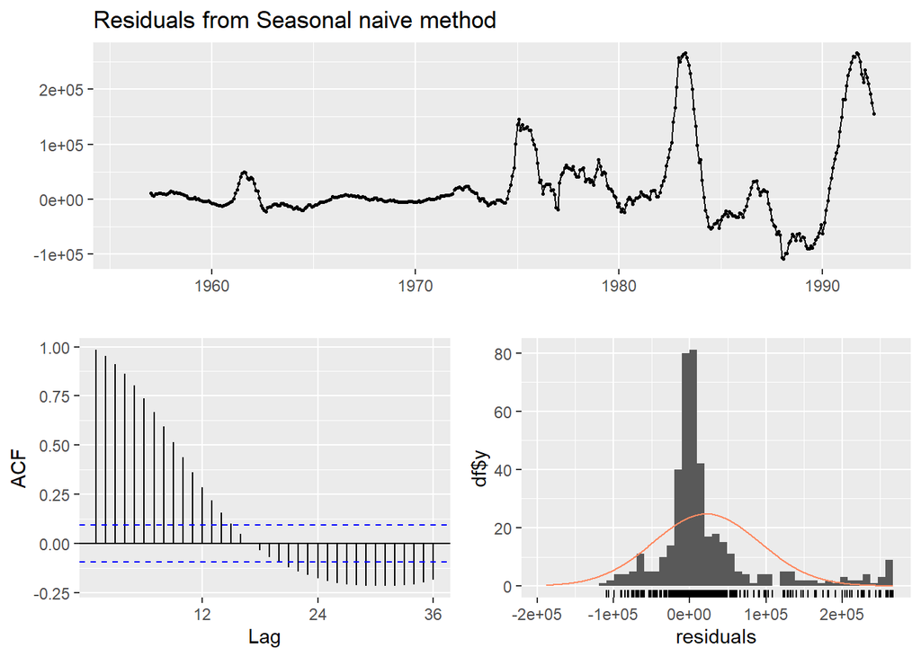

Residuals obtained with the seasonal naive method in the dole dataset

```
##
##  Ljung-Box test
##
## data:  Residuals from Seasonal naive method
## Q* = 2733.7, df = 24, p-value < 2.2e-16
##
## Model df: 0.   Total lags used: 24
```

```r
checkresiduals(dole_snaive)
```

```r
summary(residuals(dole_drift))
```

```
##    Min. 1st Qu.  Median    Mean 3rd Qu.    Max.    NA's
##  -42351   -5060   -2367       0    2371   67201       1
```

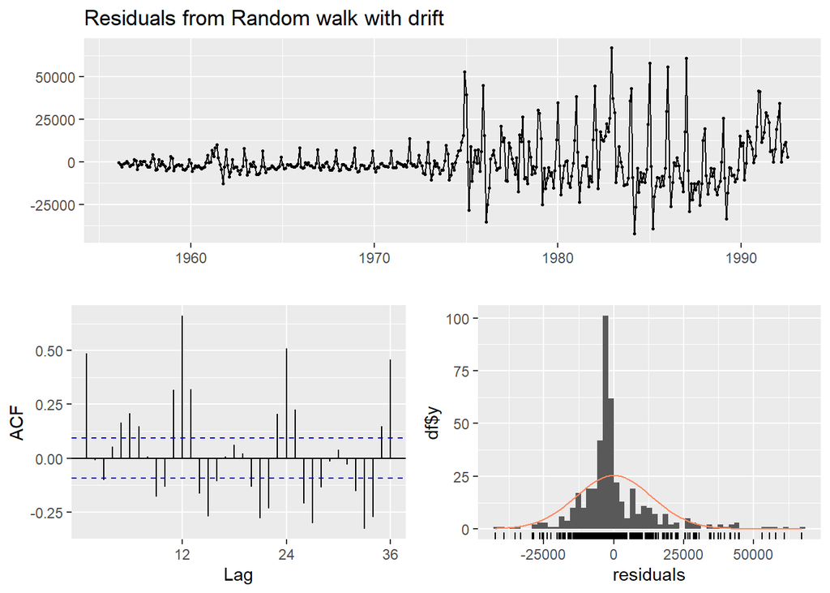

Residuals obtained with the drift method in the dole dataset

```
##
##  Ljung-Box test
##
## data:  Residuals from Random walk with drift
## Q* = 725.9, df = 23, p-value < 2.2e-16
##
## Model df: 1.   Total lags used: 24
```

```r
checkresiduals(dole_drift)
```

Again, none of the methods seems particularly correct, the naive seems the most correct among them. Now, we will do what the exercise asks for (*“graph with forecasts using the most appropriate of the four benchmark methods”*):

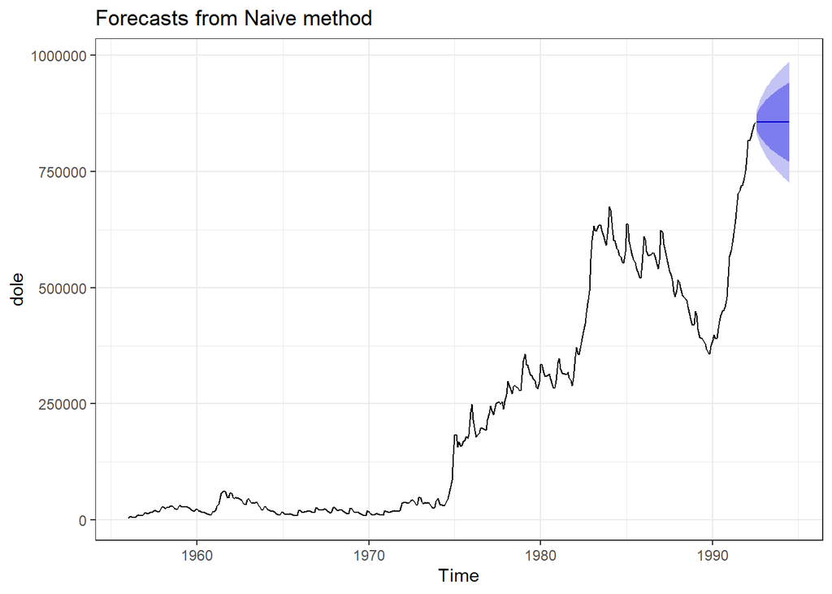

Forecasts obtained from the naive method in the dole dataset with confidence intervals (80% and 95%).

```r
autoplot(dole_naive) + theme_bw()
```

It can be seen that the confidence intervals are wide.

Forecasts do not seem reasonable for this data set using these methods. To improve them, we see two possible options:

1. Transform the data. We must take into account that Australia’s population has grown from 11.4M inhabitants to 17.5M (according to the data provided by google). This is something to take into account and it would be good to make better comparisons. In addition, there seems to be heterocedasticity in the data, so a mathematical transformation would be convenient.
2. Use more complex models. The models we have used to make predictions are really simple, and we believe that a more complex model would yield better results.

## (b)

We start again plotting the data. As the data is not seasonal, we will only use the time plot and we wont use any seasonal method.

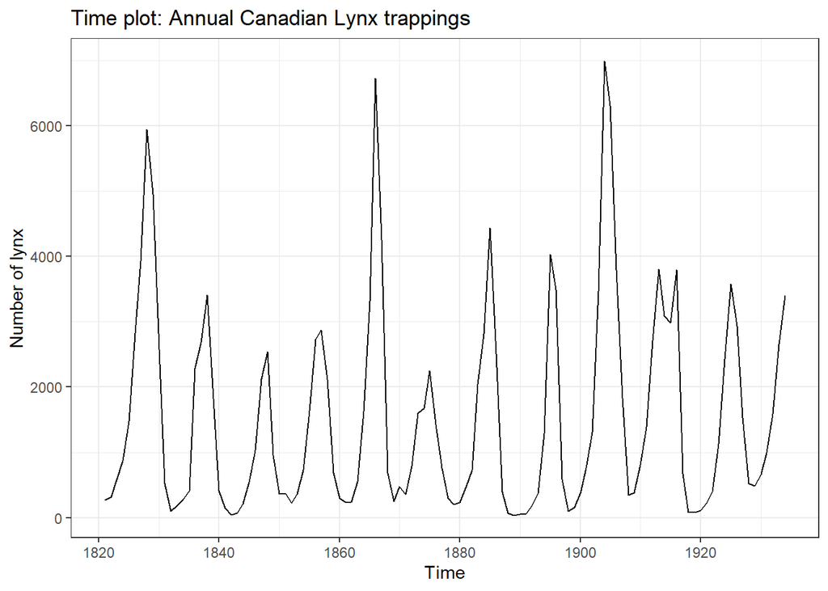

Time plot for the Annual Canadian Lynx trappings.

```r
autoplot(lynx, main = "Time plot: Annual Canadian Lynx trappings",
        xlab = "Time",
        ylab = "Number of lynx") + theme_bw()
```

As stated in Lab1b_Transformation (seem in class), this time series is stationary, although it may not appear so due to cycles, which occur when there are too many lynx for the available feed.

Next, we compute forecast with mean, naive and drift methods and plot them all

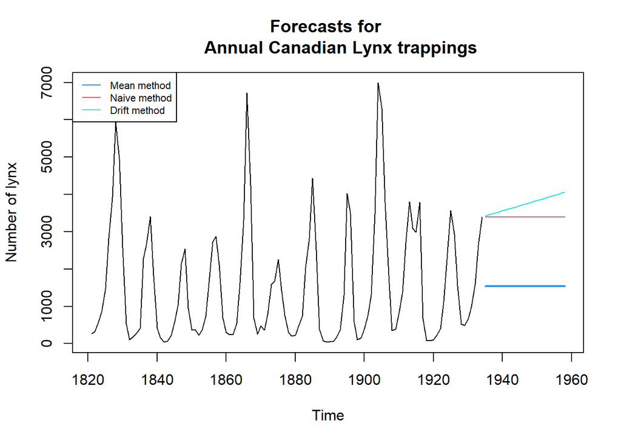

Forecasts for the Annual Canadian Lynx trappings with the mean, naive and drift methods.

```r
lynx_mean   <- meanf(lynx,h=24)
lynx_naive  <- naive(lynx,h=24)
lynx_drift  <- rwf(lynx,h=24,drift=TRUE)

plot(lynx_mean, PI=FALSE, main="Forecasts for
     Annual Canadian Lynx trappings",
    xlab = "Time",
    ylab = "Number of lynx")
lines(lynx_naive$mean, col=2)
lines(lynx_drift$mean, col=5)
legend("topleft", lty=1, cex = .7, col=c(4,2,5),
       legend=c("Mean method","Naive method","Drift method"))
```

None of the three methods seems to be doing great. Based on the above data and looking at the cycles, we would expect either a continuation of the rise or a fairly steep decline, but none of the methods make forecasts that indicate that. Let’s check the residuals.

```r
summary(residuals(lynx_mean))
```

```
##    Min. 1st Qu.  Median    Mean 3rd Qu.    Max.
##   -1499   -1190    -767       0    1029    5453
```